# Modeling proportions in Stan

Jonathan Sweeney

10/13/2017

## Why proportions?

The specific example I think about often is how to model the proportion of fish catch attributed to a set of species. Of course this is far from the only context where modeling proportions is important. Political scientists often are tasked with modeling the share of votes for each party, and marketing analysts frequently are asked about the factors that affect the market share of particular brands.

For this example, however, I’m going to think of fish.

## Simulate data

```r
rtrunc_norm <- function(n, mean, sd, lower = -Inf, upper = +Inf) {
  # This function defines a random sampling procedure for a truncated normal distribution.
  #
  samples <- vector(length = n)
  for (i in 1:n) {
    samples[i] <- rnorm(1, mean, sd)
    while (samples[i] < lower | samples[i] > upper) {
      samples[i] <- rnorm(1, mean, sd)
    }
  }
  return(samples)
}

N <- 100 # Think of this as fishing days.  Each day, some mix of fish is caught.
y1 <- rtrunc_norm(N, 10, 5, lower = 0) # Pounds of fish 1
y2 <- rtrunc_norm(N, 20, 5, lower = 0) # Pounds of fish 2
y3 <- rtrunc_norm(N, 30, 5, lower = 0) # Pounds of fish 3
```

Now, lets calculate the proportion of the daily catch for each fish type. And put it into a data set to be fit by Stan.

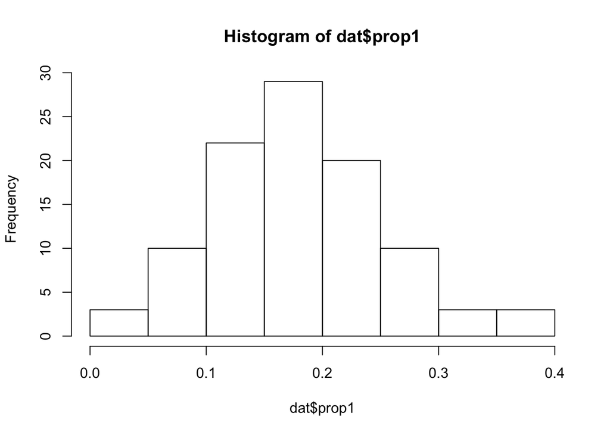

```r
prop1 <- y1 /(y1 + y2 + y3)
prop2 <- y2 /(y1 + y2 + y3)
prop3 <- y3 /(y1 + y2 + y3)

dat <- list(N = N,
            y1 = y1,
            y2 = y2,
            y3 = y3,
            prop1 = prop1,
            prop2 = prop2,
            prop3 = prop3
            )

hist(dat$prop1)
```

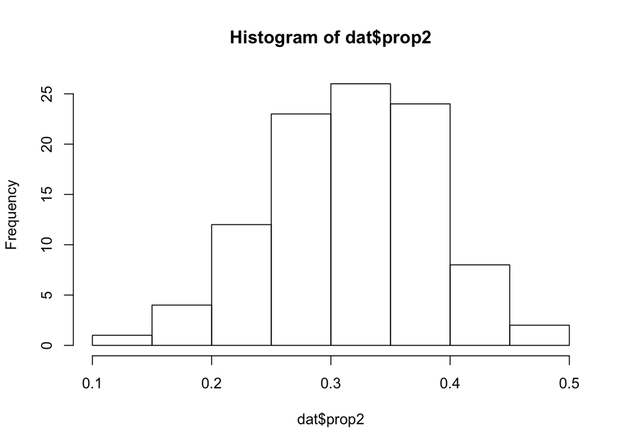

```r
hist(dat$prop2)
```

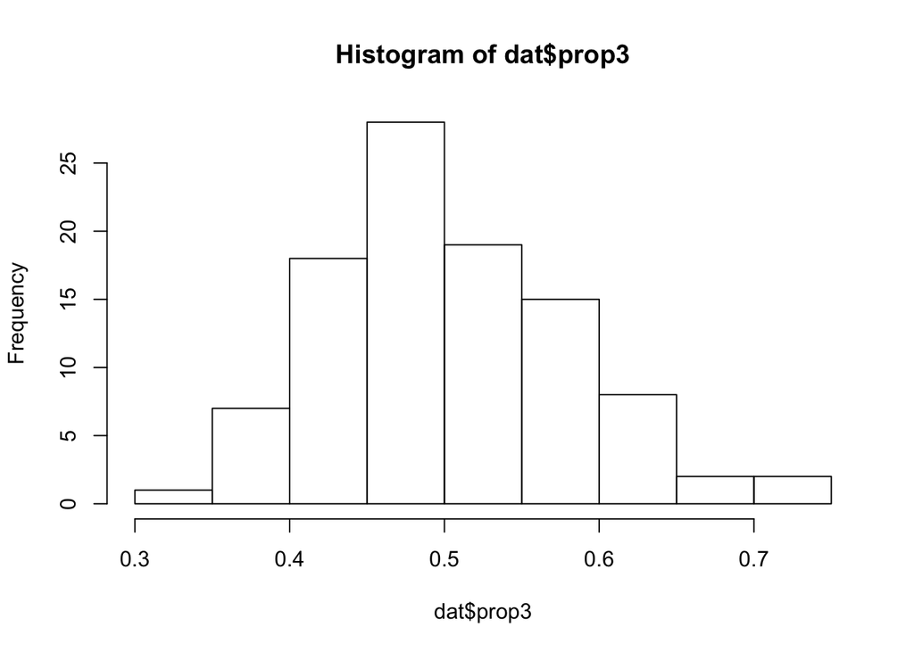

```r
hist(dat$prop3)
```

## Dirichlet model

The code below specifies the Stan code for the Dirichlet model.

```stan
data{
int N;
real prop1[N];
real prop2[N];
real prop3[N];
}
transformed data{
real prop[N,3];
for (i in 1:N) {
prop[i,1] = prop1[i];
prop[i,2] = prop2[i];
prop[i,3] = prop3[i];
}
}
parameters{
  vector<lower = 0>[3] alpha;
}
model{
for (i in 1:N)
target += dirichlet_lpdf(to_vector(prop[i,]) | alpha);
}
generated quantities{
vector[3] post_prop;
post_prop = dirichlet_rng(alpha); // Posterior predictive check.
}
```

Okay, it’s all set up. Let’s fit the model

```r
dir_fit <- sampling(dir_model, data = dat)
```

Let’s verify our model fit by plotting the alphas and posterior predicted proportions.

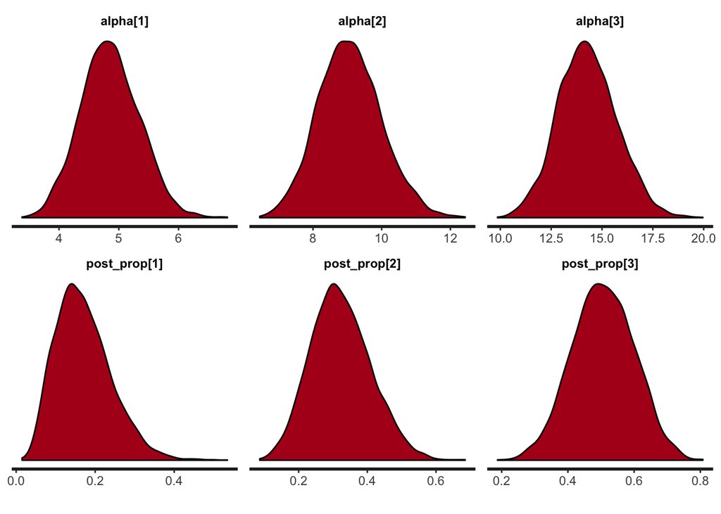

```r
stan_dens(dir_fit)
```

This actually looks very good. The posterior predicted densities line up very nicely with the historgrams of the data above.

## Beta model

For the next act, we’ll fit the same data to three beta distribution models. The beta distribution, can be thought of as a univariate Dirichlet, used frequently for modeling single proportional observations. Here, we’ll use three of them because we have three proportions.

The Stan code for the beta model is below. Note that unlike the Dirichlet distribution, which is specified by a single parameter vector alpha, each beta distribution takes two parameters an alpha and beta.

```stan
data{
int N;
real prop1[N];
real prop2[N];
real prop3[N];
}
transformed data{
real prop[N,3];
for (i in 1:N) {
prop[i,1] = prop1[i];
prop[i,2] = prop2[i];
prop[i,3] = prop3[i];
}
}
parameters{
  vector<lower = 0>[3] alpha;
  vector<lower = 0>[3] beta;
}
model{
for (i in 1:3)
target += beta_lpdf(to_vector(prop[,i]) | alpha[i], beta[i]);
}
generated quantities{
vector[3] post_prop;
for (i in 1:3) {
post_prop[i] = beta_rng(alpha[i], beta[i]); // Posterior predictive check.
}
}
```

```r
beta_fit <- sampling(beta_model, data = dat)
```

Let’s take a look at the posterior estimates, and posterior predictions.

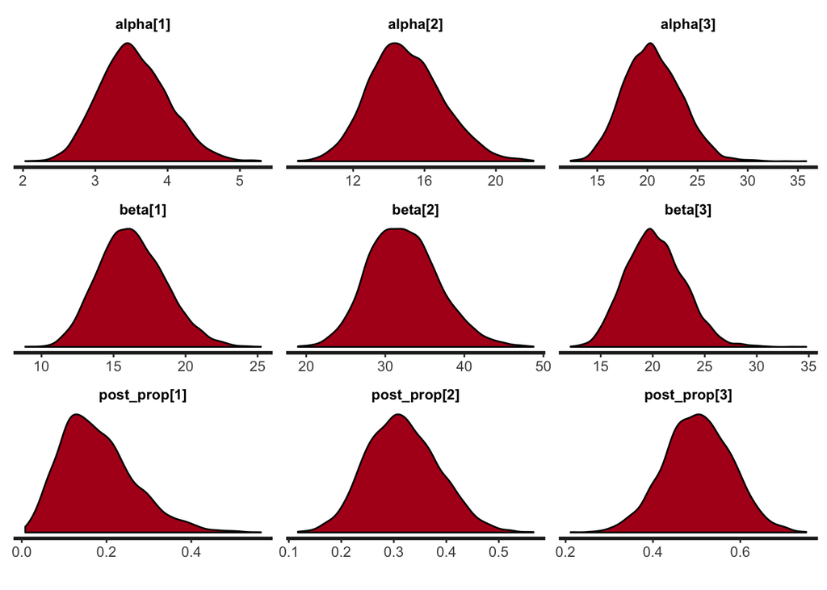

```r
stan_dens(beta_fit)
```

Although I sampled from three beta distributed parameters that modeled proportional data that summed to 1, my posterior samples don’t sum to 1. Our model therefore doesn’t yet accurately represent the data generating process (Thanks to Gelman for introducing me to posterior predictive checks). We can see this problem by running the following code.

```r
beta_fit_data <- as.data.frame(beta_fit)
beta_fit_data$sum <- beta_fit_data$`post_prop[1]`+ beta_fit_data$`post_prop[2]`+ beta_fit_data$`post_prop[3]`
head(beta_fit_data)
```

```
##   alpha[1]  alpha[2] alpha[3]   beta[1]  beta[2]  beta[3] post_prop[1]
## 1 3.571156  9.831995 20.24478 16.948134 20.99200 20.07261    0.1784483
## 2 2.987821 18.992677 24.03743 11.695166 42.96858 22.97116    0.1986967
## 3 2.318928 16.355847 16.89513  9.414351 34.65189 16.05650    0.5243581
## 4 2.999634 15.135557 15.47285 12.571763 32.14211 14.75595    0.1433880
## 5 3.174807 13.586478 24.38315 13.929121 29.79152 25.14493    0.1656136
## 6 3.003825 15.685827 20.23810 12.636652 33.26947 21.13504    0.3447155
##   post_prop[2] post_prop[3]     lp__       sum
## 1    0.4238567    0.4894529 361.9614 1.0917579
## 2    0.2619846    0.4780293 357.8948 0.9387106
## 3    0.3466669    0.5393810 357.7331 1.4104061
## 4    0.3894783    0.5174401 361.5621 1.0503065
## 5    0.4322237    0.5601387 363.0983 1.1579760
## 6    0.2892297    0.4328973 362.5067 1.0668425
```

We have to think more about how we can specify the model to address this problem. One idea is to model the data as a simplex.

```stan
data{
int N;
real prop1[N];
real prop2[N];
real prop3[N];
}
transformed data{
simplex[3] prop[N];
for (i in 1:N) {
prop[i,1] = prop1[i];
prop[i,2] = prop2[i];
prop[i,3] = prop3[i];
}
}
parameters{
  vector<lower = 0>[3] alpha;
  vector<lower = 0>[3] beta;
}
model{
for (i in 1:3)
target += beta_lpdf(to_vector(prop[,i]) | alpha[i], beta[i]);
}
generated quantities{
vector[3] post_prop;
for (i in 1:3) {
post_prop[i] = beta_rng(alpha[i], beta[i]); // Posterior predictive check.
}
}
```

```r
beta_fit_simplex <- sampling(beta_model_simplex, data = dat)
```

```r
beta_fit_simplex_data <- as.data.frame(beta_fit_simplex)
beta_fit_simplex_data$sum <- beta_fit_simplex_data$`post_prop[1]`+ beta_fit_simplex_data$`post_prop[2]`+ beta_fit_simplex_data$`post_prop[3]`
head(beta_fit_simplex_data)
```

```
##   alpha[1] alpha[2] alpha[3]  beta[1]  beta[2]  beta[3] post_prop[1]
## 1 4.259688 12.83679 24.70664 19.38331 27.15184 23.99955   0.17709154
## 2 2.989663 13.89507 21.60806 13.38600 29.99233 22.13579   0.12198795
## 3 3.456294 15.82465 20.64234 15.73905 33.00666 19.54021   0.17312871
## 4 3.466827 14.91196 21.18991 15.31545 33.19951 19.65311   0.02632261
## 5 3.539784 13.09844 22.34605 17.24696 29.17242 20.72027   0.03205031
## 6 3.374164 13.47410 21.09077 17.99689 29.56165 21.44680   0.25622786
##   post_prop[2] post_prop[3]     lp__       sum
## 1    0.2939576    0.4795089 363.7138 0.9505580
## 2    0.3383869    0.4925891 364.3952 0.9529640
## 3    0.2475298    0.6402783 364.9288 1.0609368
## 4    0.2854827    0.5930115 363.8308 0.9048168
## 5    0.3705119    0.4347848 363.0833 0.8373470
## 6    0.2605067    0.3783492 362.2010 0.8950837
```

Nope, that didn’t work. However, because we know the data is a simplex, that means we only need to model p-1 parameters. If we define a beta distribution for the first and second, the third is given. This means we only need to sample two parameters, and the third will be what’s left over, ensuring our posterior predictions sum to 1.

```stan
data{
int N;
real prop1[N];
real prop2[N];
}
transformed data{
real prop[N,2];
for (i in 1:N) {
prop[i,1] = prop1[i];
prop[i,2] = prop2[i];
}
}
parameters{
  vector<lower = 0>[2] alpha;
  vector<lower = 0>[2] beta;
}
model{
for (i in 1:2)
target += beta_lpdf(to_vector(prop[,i]) | alpha[i], beta[i]);
}
generated quantities{
vector[2] post_prop;
for (i in 1:2) {
post_prop[i] = beta_rng(alpha[i], beta[i]); // Posterior predictive check.
}
}
```

```r
beta_fit_2 <- sampling(beta_model_2, data = dat)
beta_fit_2_data <- as.data.frame(beta_fit_2)
beta_fit_2_data$p3 <- 1 - (beta_fit_2_data$`post_prop[1]`+ beta_fit_2_data$`post_prop[2]`)
beta_fit_2_data$sum <- beta_fit_2_data$p3+beta_fit_2_data$`post_prop[1]`+ beta_fit_2_data$`post_prop[2]`
head(beta_fit_2_data)
```

[output not shown]

## Beta models with predictors

What if we observed predictors of our proportional observations? Greg Snow introduced a reparameterization needed for a beta regression. $\alpha=\mu \times \phi$, and $\beta = (1- \mu)\times \phi$. Then, you just predict $\mu$ using your predictors, making sure to constrain it to be greater than 0.

We’ll need to first simulate some additional data for the predictors. Let’s assume the predictor $x$, is positively related to proportion of output 1.

```r
x <- 1.5 * y1
dat_x <- list(N = N,
            x = x,
            y1 = y1,
            y2 = y2,
            y3 = y3,
            prop1 = prop1,
            prop2 = prop2,
            prop3 = prop3
            )
```

Now, the new reparameterized Stan model.

```stan
data{
int N;
real prop1[N];
real prop2[N];
real x[N];
}
transformed data{
real prop[N,2];
for (i in 1:N) {
prop[i,1] = prop1[i];
prop[i,2] = prop2[i];
}
}
parameters{
  real<lower = 0> alpha2;
  real<lower = 0> beta2;
  real<lower = 0> phi;
  real<lower = 0> mu;
  real b;
}
transformed parameters{
  real<lower = 0> alpha1;
  real<lower = 0> beta1;
  alpha1 = mu * phi;
  beta1 = (1 - mu) * phi;
}
model{
for (i in 1:N) {
  target += exponential_lpdf(mu | b * x[i]);
  target += beta_lpdf(prop[i,1] | alpha1, beta1);
  target += beta_lpdf(prop[i,2] | alpha2, beta2);
}
}
generated quantities{
vector[2] post_prop;
post_prop[1] = beta_rng(alpha1, beta1); // Posterior predictive check.
post_prop[2] = beta_rng(alpha2, beta2);
}
```

```r
beta_fit_x <- sampling(beta_model_x, data = dat_x)
```

[output not shown]

[output cut: 60 more lines]

[output not shown]

```r
print(beta_fit_x)
```

```
## Inference for Stan model: 1e6cc085f8b5d451feb94da0c0e02c29.
## 4 chains, each with iter=2000; warmup=1000; thin=1;
## post-warmup draws per chain=1000, total post-warmup draws=4000.
##
##                mean se_mean   sd   2.5%    25%    50%    75%  97.5% n_eff
## alpha2        14.93    0.05 2.12  11.15  13.44  14.80  16.37  19.22  1652
## beta2         32.25    0.11 4.59  23.92  29.03  31.99  35.32  41.51  1670
## phi           18.39    0.06 2.72  13.49  16.54  18.22  20.18  24.01  2269
## mu             0.13    0.00 0.01   0.11   0.13   0.13   0.14   0.15  1987
## b              0.46    0.00 0.06   0.35   0.42   0.45   0.49   0.58  1992
## alpha1         2.45    0.01 0.47   1.60   2.13   2.43   2.76   3.44  1940
## beta1         15.94    0.05 2.28  11.74  14.35  15.82  17.43  20.68  2373
## post_prop[1]   0.13    0.00 0.08   0.02   0.07   0.12   0.18   0.32  4000
## post_prop[2]   0.32    0.00 0.07   0.19   0.27   0.31   0.36   0.46  3885
## lp__         310.37    0.04 1.63 306.41 309.57 310.67 311.57 312.57  1642
##              Rhat
## alpha2          1
## beta2           1
## phi             1
## mu              1
## b               1
## alpha1          1
## beta1           1
## post_prop[1]    1
## post_prop[2]    1
## lp__            1
##
## Samples were drawn using NUTS(diag_e) at Wed Oct 18 11:09:06 2017.
## For each parameter, n_eff is a crude measure of effective sample size,
## and Rhat is the potential scale reduction factor on split chains (at
## convergence, Rhat=1).
```

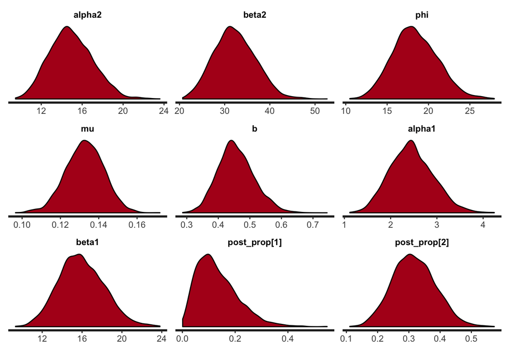

```r
stan_dens(beta_fit_x)
```